# Codebook for Human Activity Table (data)

## FFT BodyGyro-mean-Y

| Feature | Result |
| --- | --- |
| Variable type | numeric |
| Number of missing obs. | 0 (0 %) |
| Number of unique values | 10296 |
| Median | -0.92 |
| 1st and 3rd quartiles | -0.98; -0.47 |
| Min. and max. | -1; 1 |

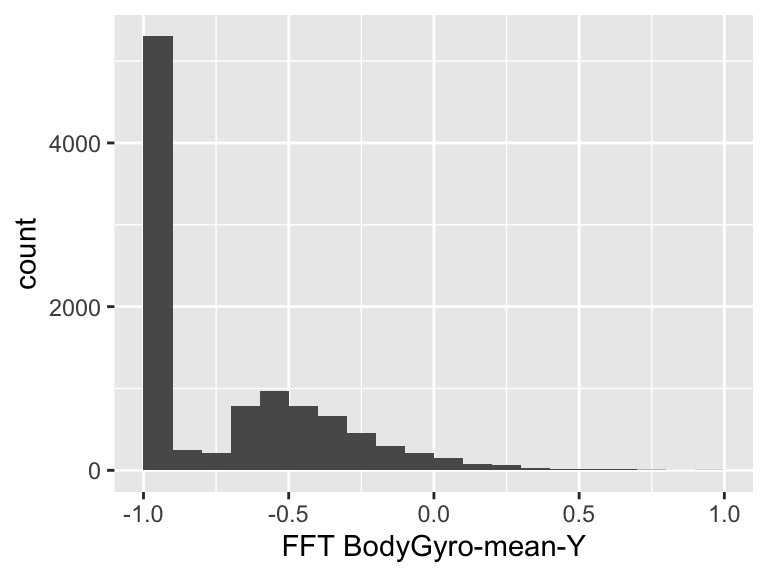

## FFT BodyGyro-mean-Z

| Feature | Result |
| --- | --- |
| Variable type | numeric |
| Number of missing obs. | 0 (0 %) |
| Number of unique values | 10297 |
| Median | -0.89 |
| 1st and 3rd quartiles | -0.99; -0.32 |
| Min. and max. | -1; 1 |

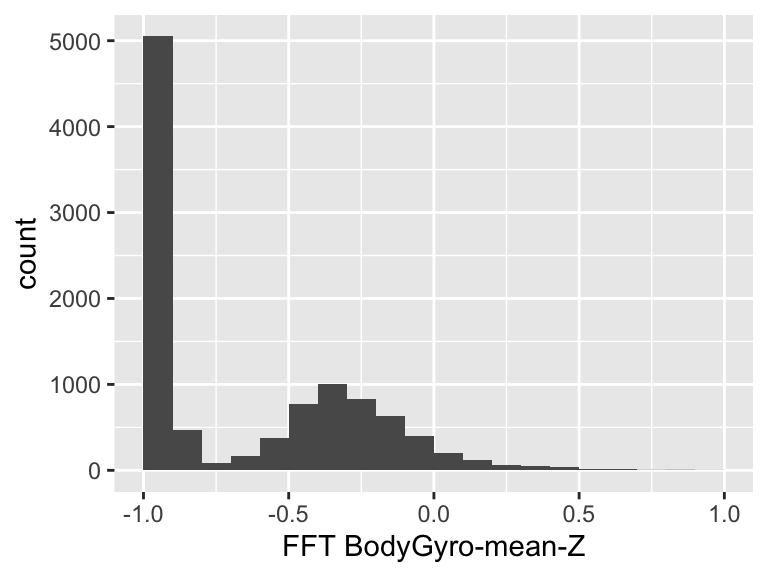

## FFT BodyAccMag-mean

| Feature | Result |
| --- | --- |
| Variable type | numeric |
| Number of missing obs. | 0 (0 %) |
| Number of unique values | 10296 |
| Median | -0.88 |
| 1st and 3rd quartiles | -0.98; -0.22 |
| Min. and max. | -1; 1 |

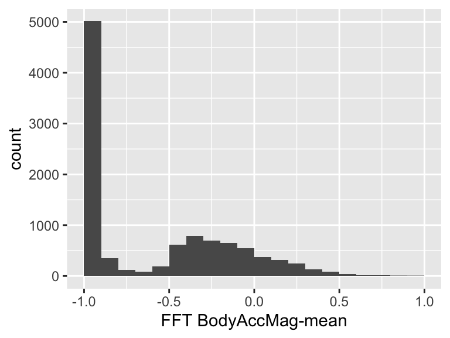

## FFT BodyBodyAccJerkMag-mean

| Feature | Result |
| --- | --- |
| Variable type | numeric |
| Number of missing obs. | 0 (0 %) |
| Number of unique values | 10290 |
| Median | -0.93 |
| 1st and 3rd quartiles | -0.99; -0.26 |
| Min. and max. | -1; 1 |

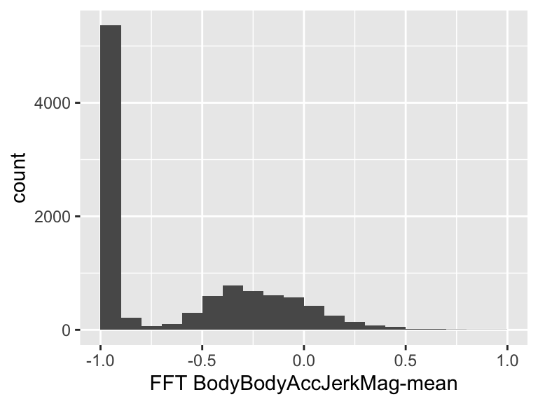

## FFT BodyBodyGyroMag-mean

| Feature | Result |
| --- | --- |
| Variable type | numeric |
| Number of missing obs. | 0 (0 %) |
| Number of unique values | 10297 |
| Median | -0.88 |
| 1st and 3rd quartiles | -0.98; -0.45 |
| Min. and max. | -1; 1 |

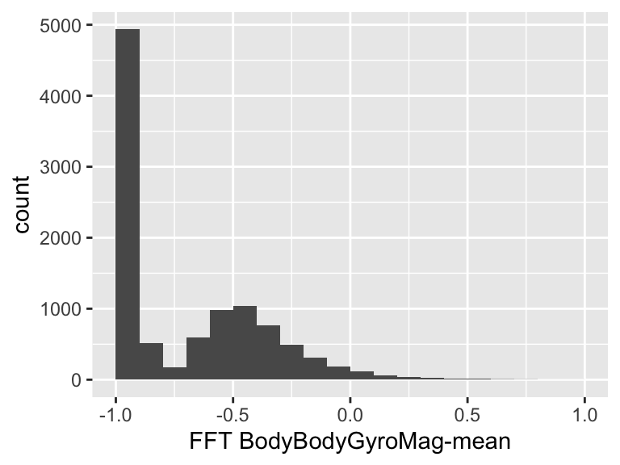

## FFT BodyBodyGyroJerkMag-mean

| Feature | Result |
| --- | --- |
| Variable type | numeric |
| Number of missing obs. | 0 (0 %) |
| Number of unique values | 10293 |
| Median | -0.95 |
| 1st and 3rd quartiles | -0.99; -0.61 |
| Min. and max. | -1; 1 |

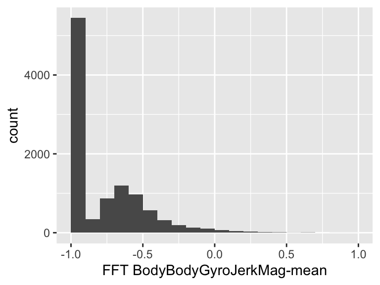

## Time BodyAcc-std-X

| Feature | Result |
| --- | --- |
| Variable type | numeric |
| Number of missing obs. | 0 (0 %) |
| Number of unique values | 10295 |
| Median | -0.94 |
| 1st and 3rd quartiles | -0.99; -0.25 |
| Min. and max. | -1; 1 |

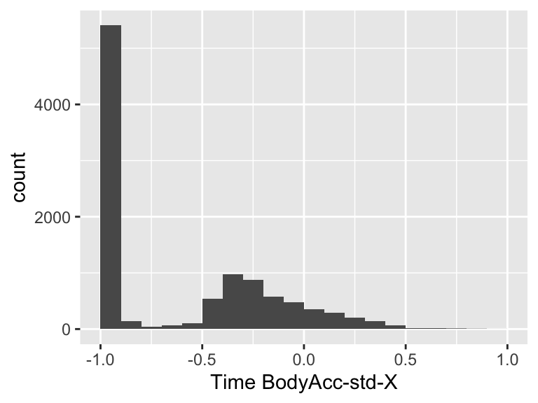

## Time BodyAcc-std-Y

| Feature | Result |
| --- | --- |
| Variable type | numeric |
| Number of missing obs. | 0 (0 %) |
| Number of unique values | 10297 |
| Median | -0.84 |
| 1st and 3rd quartiles | -0.98; -0.06 |
| Min. and max. | -1; 1 |

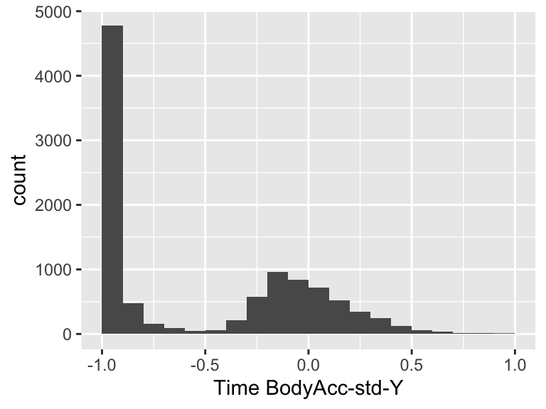

## Time BodyAcc-std-Z

| Feature | Result |
| --- | --- |
| Variable type | numeric |
| Number of missing obs. | 0 (0 %) |
| Number of unique values | 10297 |
| Median | -0.85 |
| 1st and 3rd quartiles | -0.98; -0.28 |
| Min. and max. | -1; 1 |

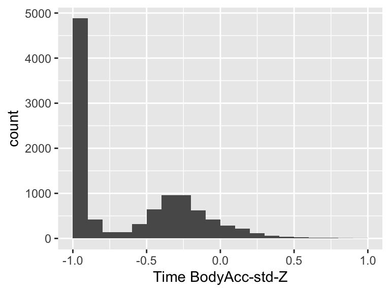

## Time GravityAcc-std-X

| Feature | Result |
| --- | --- |
| Variable type | numeric |
| Number of missing obs. | 0 (0 %) |
| Number of unique values | 10288 |
| Median | -0.98 |
| 1st and 3rd quartiles | -0.99; -0.96 |
| Min. and max. | -1; 1 |

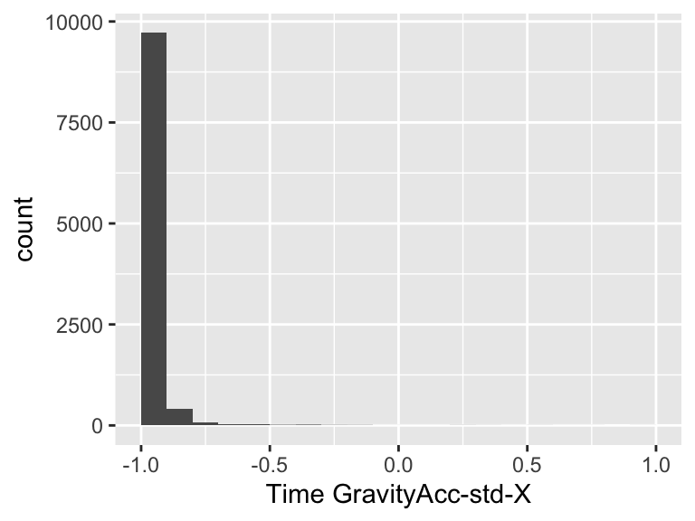

## Time GravityAcc-std-Y

| Feature | Result |
| --- | --- |
| Variable type | numeric |
| Number of missing obs. | 0 (0 %) |
| Number of unique values | 10293 |
| Median | -0.98 |
| 1st and 3rd quartiles | -0.99; -0.95 |
| Min. and max. | -1; 1 |

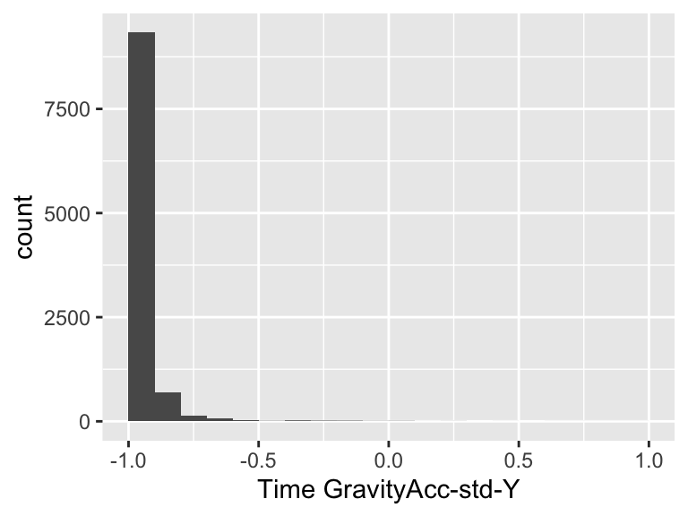

## Time GravityAcc-std-Z

| Feature | Result |
| --- | --- |
| Variable type | numeric |
| Number of missing obs. | 0 (0 %) |
| Number of unique values | 10296 |
| Median | -0.97 |
| 1st and 3rd quartiles | -0.99; -0.93 |
| Min. and max. | -1; 1 |

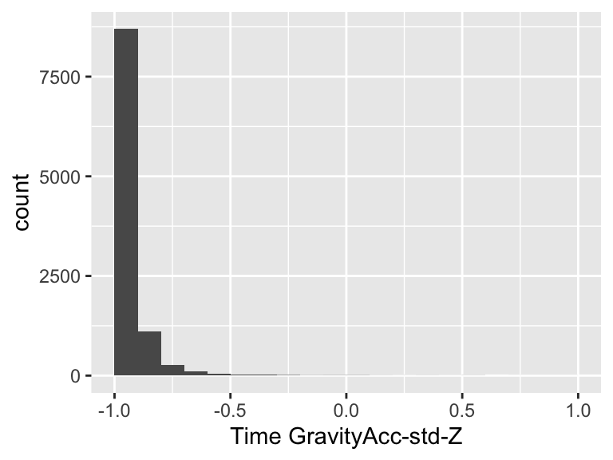

## Time BodyAccJerk-std-X

| Feature | Result |
| --- | --- |
| Variable type | numeric |
| Number of missing obs. | 0 (0 %) |
| Number of unique values | 10290 |
| Median | -0.95 |
| 1st and 3rd quartiles | -0.99; -0.29 |
| Min. and max. | -1; 1 |

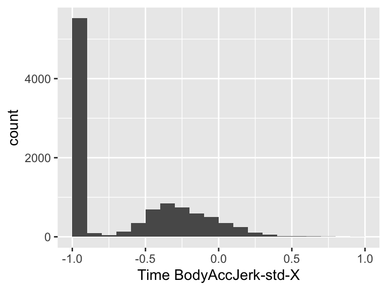

## Time BodyAccJerk-std-Y

| Feature | Result |
| --- | --- |
| Variable type | numeric |
| Number of missing obs. | 0 (0 %) |
| Number of unique values | 10296 |
| Median | -0.93 |
| 1st and 3rd quartiles | -0.99; -0.22 |
| Min. and max. | -1; 1 |

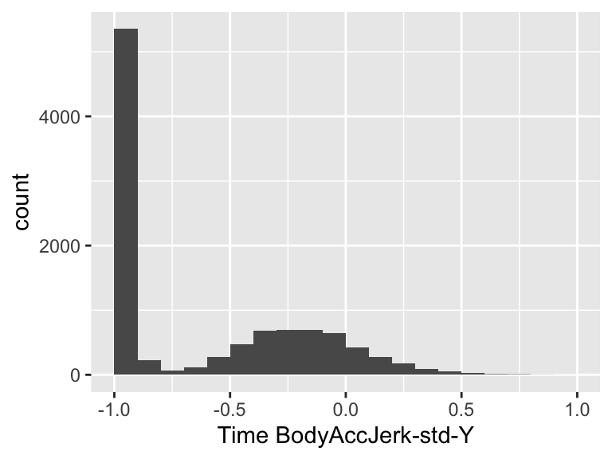

## Time BodyAccJerk-std-Z

| Feature | Result |
| --- | --- |
| Variable type | numeric |
| Number of missing obs. | 0 (0 %) |
| Number of unique values | 10293 |
| Median | -0.95 |
| 1st and 3rd quartiles | -0.99; -0.55 |
| Min. and max. | -1; 1 |

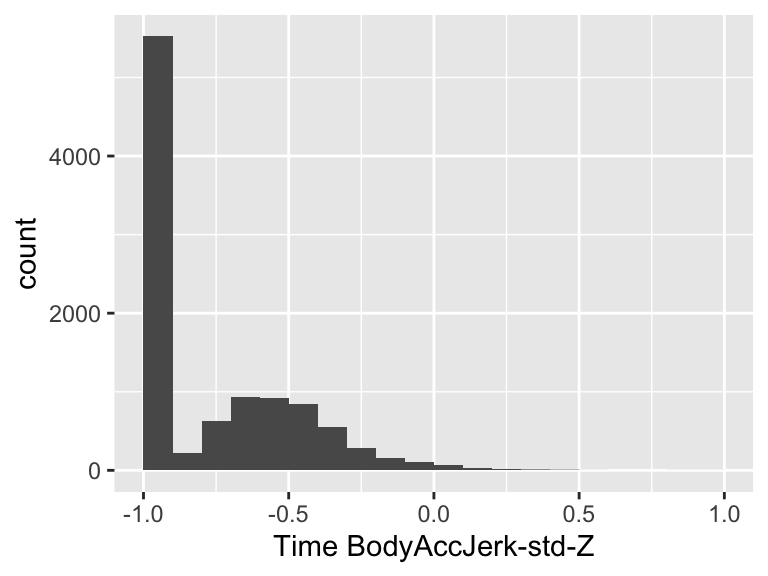

## Time BodyGyro-std-X

| Feature | Result |
| --- | --- |
| Variable type | numeric |
| Number of missing obs. | 0 (0 %) |
| Number of unique values | 10292 |
| Median | -0.9 |
| 1st and 3rd quartiles | -0.99; -0.48 |
| Min. and max. | -1; 1 |

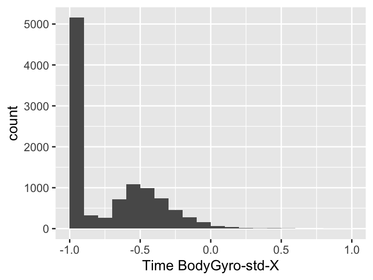

## Time BodyGyro-std-Y

| Feature | Result |
| --- | --- |
| Variable type | numeric |
| Number of missing obs. | 0 (0 %) |
| Number of unique values | 10296 |
| Median | -0.91 |
| 1st and 3rd quartiles | -0.98; -0.45 |
| Min. and max. | -1; 1 |

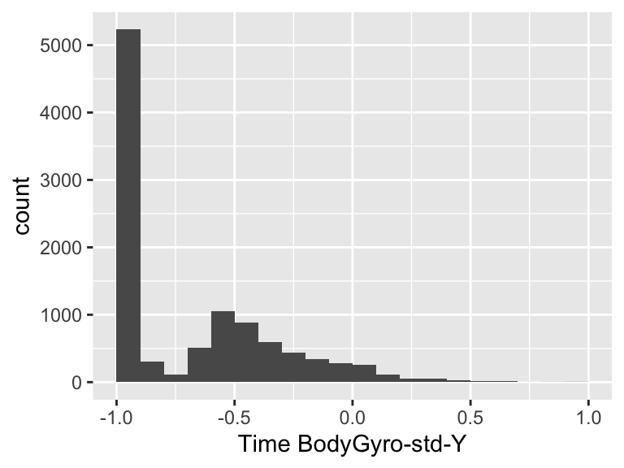

## Time BodyGyro-std-Z

| Feature | Result |
| --- | --- |
| Variable type | numeric |
| Number of missing obs. | 0 (0 %) |
| Number of unique values | 10296 |
| Median | -0.88 |
| 1st and 3rd quartiles | -0.99; -0.34 |
| Min. and max. | -1; 1 |

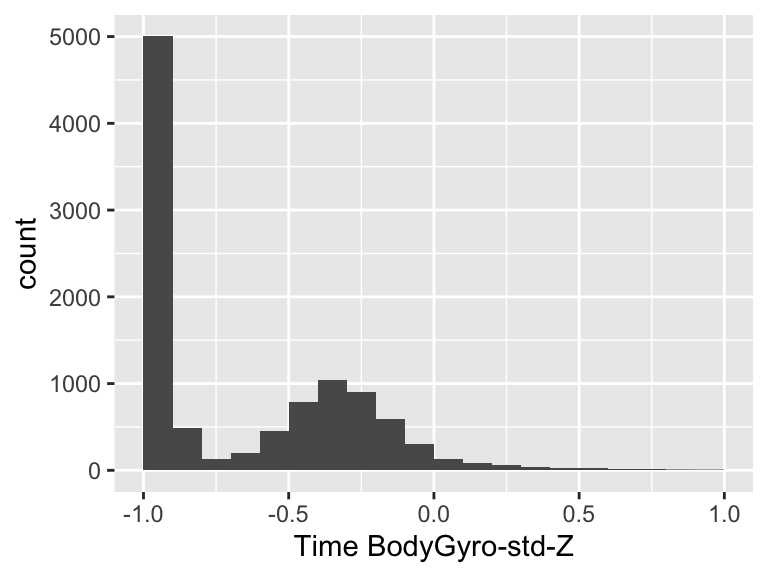

## Time BodyGyroJerk-std-X

| Feature | Result |
| --- | --- |
| Variable type | numeric |
| Number of missing obs. | 0 (0 %) |
| Number of unique values | 10292 |
| Median | -0.93 |
| 1st and 3rd quartiles | -0.99; -0.49 |
| Min. and max. | -1; 1 |

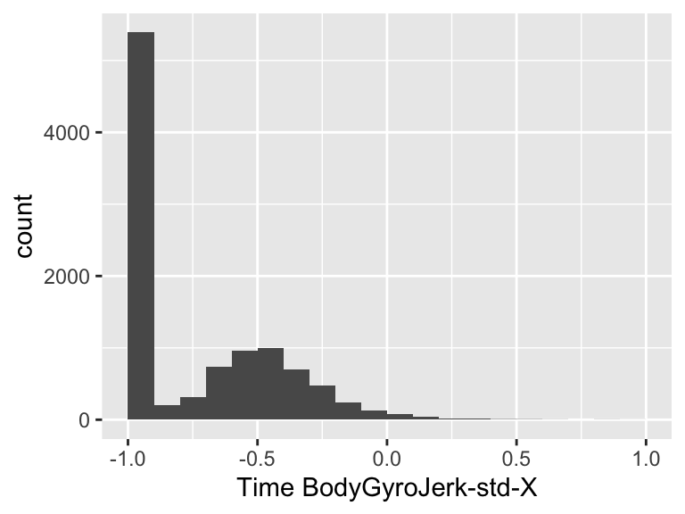

## Time BodyGyroJerk-std-Y

| Feature | Result |
| --- | --- |
| Variable type | numeric |
| Number of missing obs. | 0 (0 %) |
| Number of unique values | 10295 |
| Median | -0.95 |
| 1st and 3rd quartiles | -0.99; -0.63 |
| Min. and max. | -1; 1 |

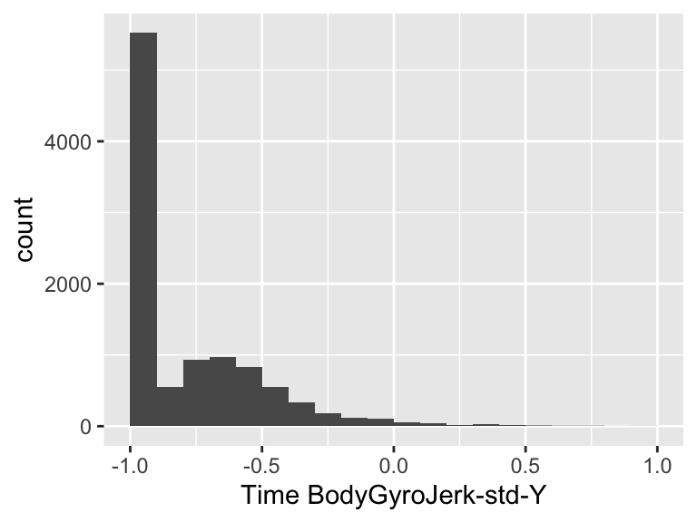

## Time BodyGyroJerk-std-Z

| Feature | Result |
| --- | --- |
| Variable type | numeric |
| Number of missing obs. | 0 (0 %) |
| Number of unique values | 10291 |
| Median | -0.95 |
| 1st and 3rd quartiles | -0.99; -0.51 |
| Min. and max. | -1; 1 |

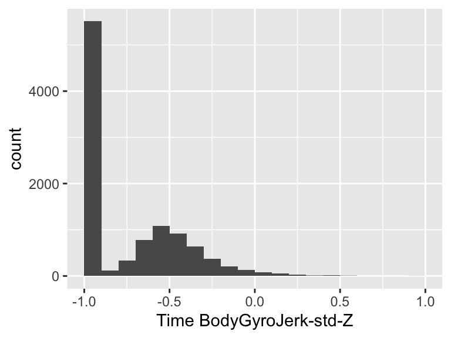

## Time BodyAccMag-std

| Feature | Result |
| --- | --- |
| Variable type | numeric |
| Number of missing obs. | 0 (0 %) |
| Number of unique values | 10294 |
| Median | -0.84 |
| 1st and 3rd quartiles | -0.98; -0.24 |
| Min. and max. | -1; 1 |

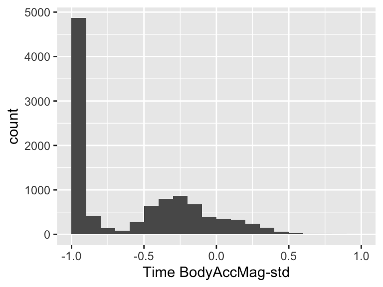

## Time GravityAccMag-std

| Feature | Result |
| --- | --- |
| Variable type | numeric |
| Number of missing obs. | 0 (0 %) |
| Number of unique values | 10294 |
| Median | -0.84 |
| 1st and 3rd quartiles | -0.98; -0.24 |
| Min. and max. | -1; 1 |

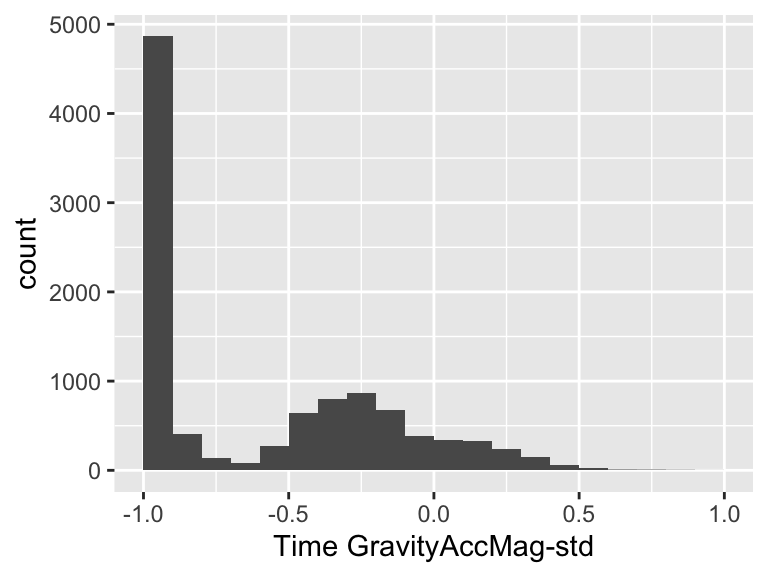

## Time BodyAccJerkMag-std

| Feature | Result |
| --- | --- |
| Variable type | numeric |
| Number of missing obs. | 0 (0 %) |
| Number of unique values | 10294 |
| Median | -0.93 |
| 1st and 3rd quartiles | -0.99; -0.27 |
| Min. and max. | -1; 1 |

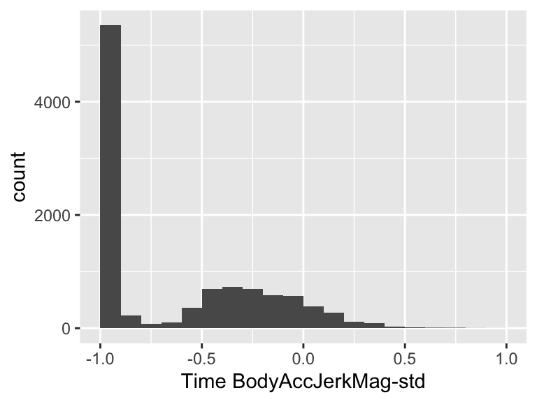

## Time BodyGyroMag-std

| Feature | Result |
| --- | --- |
| Variable type | numeric |
| Number of missing obs. | 0 (0 %) |
| Number of unique values | 10298 |
| Median | -0.83 |
| 1st and 3rd quartiles | -0.98; -0.39 |
| Min. and max. | -1; 1 |

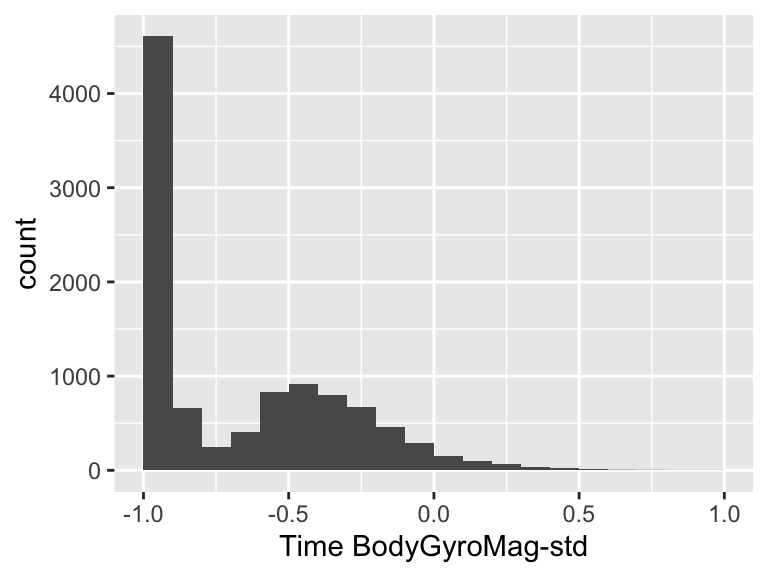

## Time BodyGyroJerkMag-std

| Feature | Result |
| --- | --- |
| Variable type | numeric |
| Number of missing obs. | 0 (0 %) |
| Number of unique values | 10297 |
| Median | -0.94 |
| 1st and 3rd quartiles | -0.99; -0.61 |
| Min. and max. | -1; 1 |

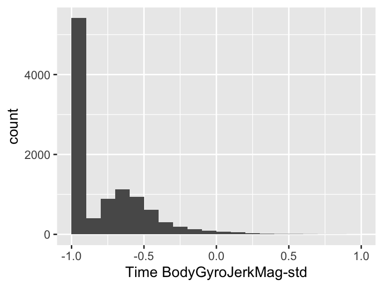

## FFT BodyAcc-std-X

| Feature | Result |
| --- | --- |
| Variable type | numeric |
| Number of missing obs. | 0 (0 %) |
| Number of unique values | 10294 |
| Median | -0.94 |
| 1st and 3rd quartiles | -0.99; -0.25 |
| Min. and max. | -1; 1 |

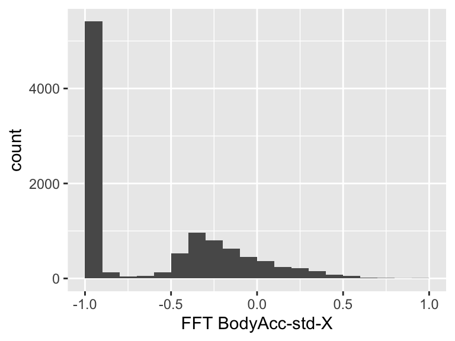

## FFT BodyAcc-std-Y

| Feature | Result |
| --- | --- |
| Variable type | numeric |
| Number of missing obs. | 0 (0 %) |
| Number of unique values | 10297 |
| Median | -0.83 |
| 1st and 3rd quartiles | -0.98; -0.09 |
| Min. and max. | -1; 1 |

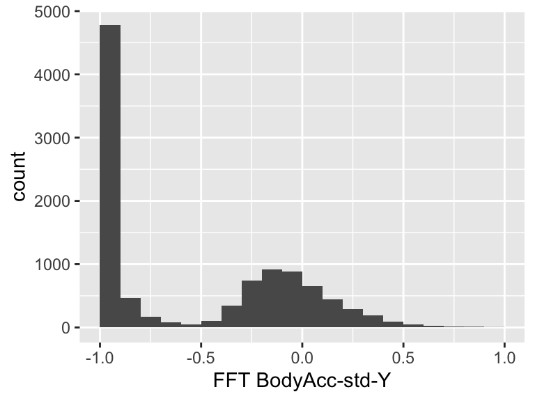

## FFT BodyAcc-std-Z

| Feature | Result |
| --- | --- |
| Variable type | numeric |
| Number of missing obs. | 0 (0 %) |
| Number of unique values | 10296 |
| Median | -0.84 |
| 1st and 3rd quartiles | -0.98; -0.3 |
| Min. and max. | -1; 1 |

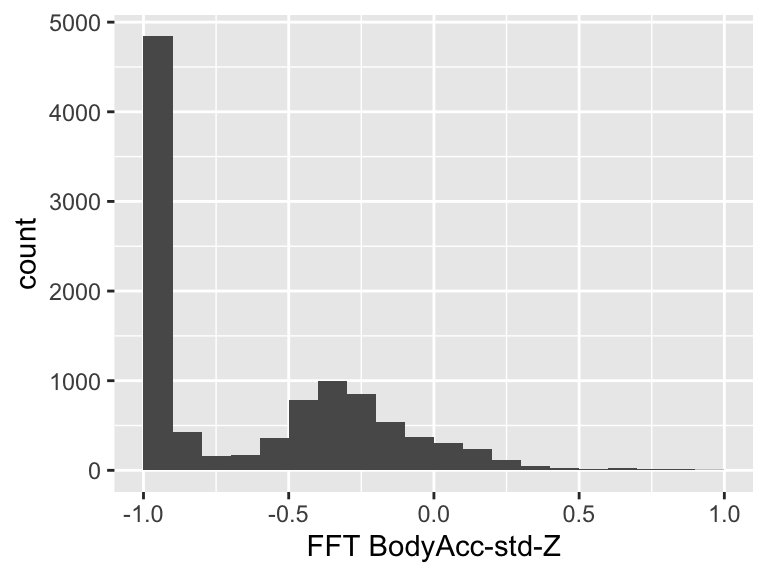

## FFT BodyAccJerk-std-X

| Feature | Result |
| --- | --- |
| Variable type | numeric |
| Number of missing obs. | 0 (0 %) |
| Number of unique values | 10291 |
| Median | -0.96 |
| 1st and 3rd quartiles | -0.99; -0.32 |
| Min. and max. | -1; 1 |

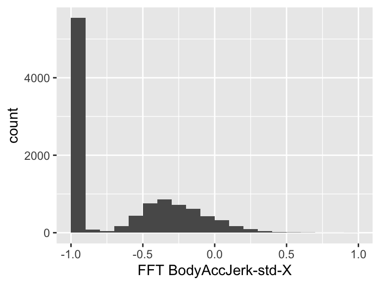

## FFT BodyAccJerk-std-Y

| Feature | Result |
| --- | --- |
| Variable type | numeric |
| Number of missing obs. | 0 (0 %) |
| Number of unique values | 10294 |
| Median | -0.93 |
| 1st and 3rd quartiles | -0.99; -0.24 |
| Min. and max. | -1; 1 |

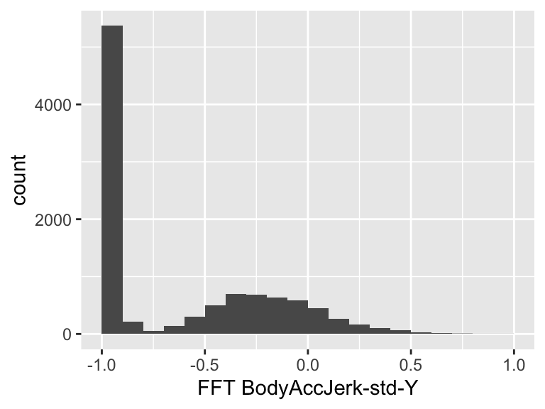

## FFT BodyAccJerk-std-Z

| Feature | Result |
| --- | --- |
| Variable type | numeric |
| Number of missing obs. | 0 (0 %) |
| Number of unique values | 10290 |
| Median | -0.96 |
| 1st and 3rd quartiles | -0.99; -0.59 |
| Min. and max. | -1; 1 |

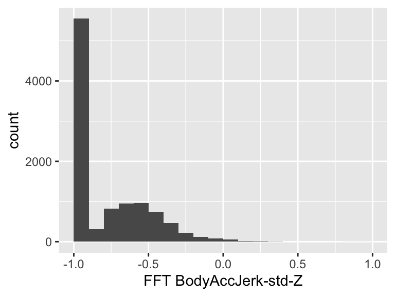

## FFT BodyGyro-std-X

| Feature | Result |
| --- | --- |
| Variable type | numeric |
| Number of missing obs. | 0 (0 %) |
| Number of unique values | 10297 |
| Median | -0.91 |
| 1st and 3rd quartiles | -0.99; -0.52 |
| Min. and max. | -1; 1 |

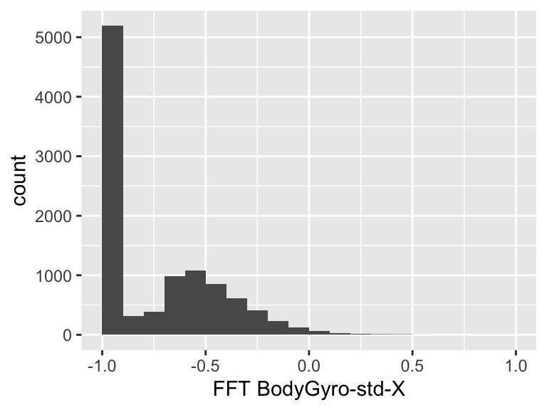

## FFT BodyGyro-std-Y

| Feature | Result |
| --- | --- |
| Variable type | numeric |
| Number of missing obs. | 0 (0 %) |
| Number of unique values | 10293 |
| Median | -0.91 |
| 1st and 3rd quartiles | -0.98; -0.44 |
| Min. and max. | -1; 1 |

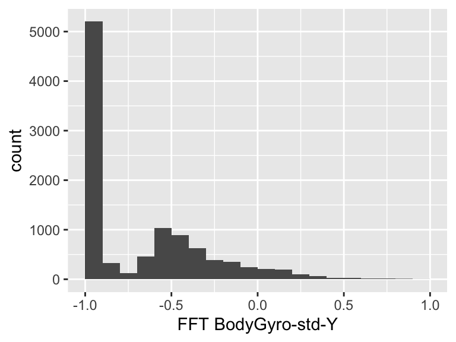

## FFT BodyGyro-std-Z

| Feature | Result |
| --- | --- |
| Variable type | numeric |
| Number of missing obs. | 0 (0 %) |
| Number of unique values | 10295 |
| Median | -0.89 |
| 1st and 3rd quartiles | -0.99; -0.42 |
| Min. and max. | -1; 1 |

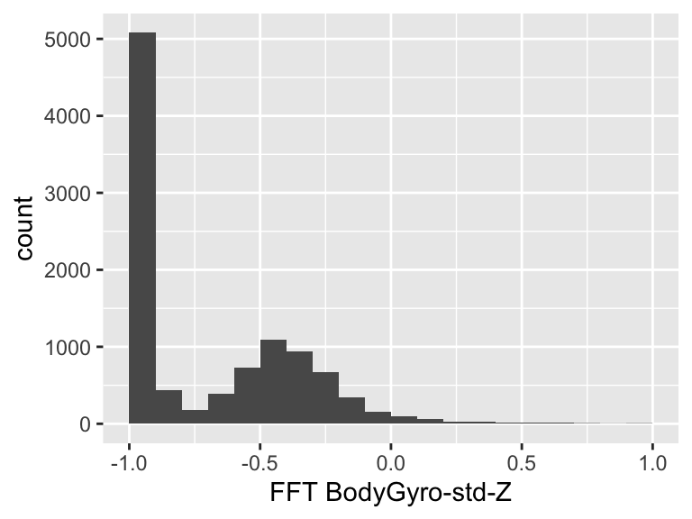

## FFT BodyAccMag-std

| Feature | Result |
| --- | --- |
| Variable type | numeric |
| Number of missing obs. | 0 (0 %) |
| Number of unique values | 10298 |
| Median | -0.85 |
| 1st and 3rd quartiles | -0.98; -0.38 |
| Min. and max. | -1; 1 |

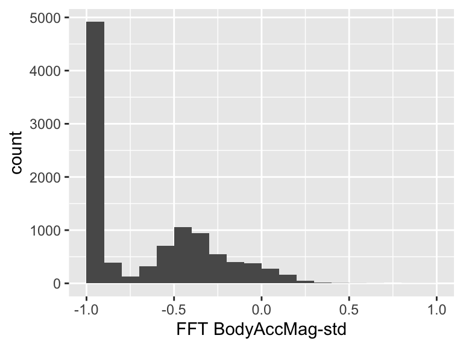

## FFT BodyBodyAccJerkMag-std

| Feature | Result |
| --- | --- |
| Variable type | numeric |
| Number of missing obs. | 0 (0 %) |
| Number of unique values | 10296 |
| Median | -0.93 |
| 1st and 3rd quartiles | -0.99; -0.31 |
| Min. and max. | -1; 1 |

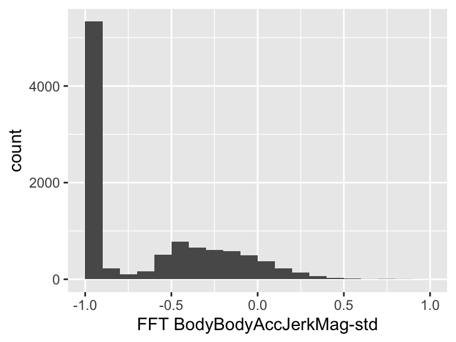

## FFT BodyBodyGyroMag-std

| Feature | Result |
| --- | --- |
| Variable type | numeric |
| Number of missing obs. | 0 (0 %) |
| Number of unique values | 10296 |
| Median | -0.83 |
| 1st and 3rd quartiles | -0.98; -0.47 |
| Min. and max. | -1; 1 |

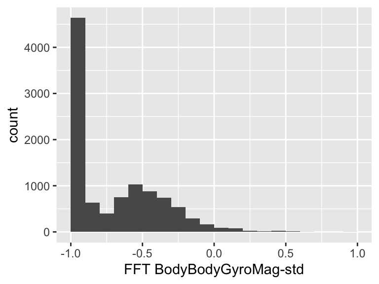

## FFT BodyBodyGyroJerkMag-std

| Feature | Result |
| --- | --- |
| Variable type | numeric |
| Number of missing obs. | 0 (0 %) |
| Number of unique values | 10292 |
| Median | -0.94 |
| 1st and 3rd quartiles | -0.99; -0.64 |
| Min. and max. | -1; 1 |

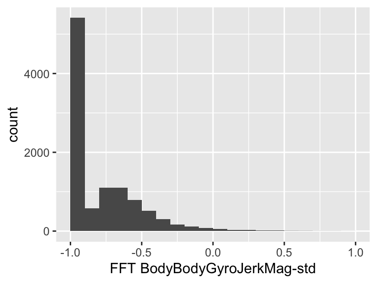

Report generation information:

- Created by: Denis Levert (username: `DenisLevert`).
- Report creation time: Sun Aug 30 2020 09:39:23
- Report was run from directory: `/Users/DenisLevert/Documents/R/R_School/CleanData/Project/HumanActivity`
- dataMaid v1.4.0 [Pkg: 2019-12-10 from CRAN (R 4.0.2)]
- R version 4.0.2 (2020-06-22).
- Platform: x86_64-apple-darwin17.0 (64-bit)(macOS Catalina 10.15.6).
- Function call: `dataMaid::makeDataReport(data = data, mode = c("summarize", "visualize", "check"), smartNum = FALSE, file = "codebook_data.Rmd", checks = list( character = "showAllFactorLevels", factor = "showAllFactorLevels", labelled = "showAllFactorLevels", haven_labelled = "showAllFactorLevels", numeric = NULL, integer = NULL, logical = NULL, Date = NULL), listChecks = FALSE, maxProbVals = Inf, codebook = TRUE, reportTitle = "Codebook for data")`